# Student Housing Costs

## Background

Stephanie[^1] is a student that will be starting school at BYU-Idaho next semester. Here is a copy of the email request for information that she sent.

“Hi. My name is Stephanie. I would like to learn about what housing options I have for living at BYU-Idaho next semester. It will be my first semester there, so I would like to find something that is close to campus and around $300 a month in rent. I’m not too picky on roomates, but I would like somewhere that has a lot of people around so I can get to know as many people as possible. Thanks in advance!”

Here is the list of 55 female apartments that list their semester rent on the [BYU-Idaho Housing Website](https://web.byui.edu/tis/search).

### Dataset of Female Housing

|  | Apartment | Gender | Address | Phone | Cost | CostHigh | Residents | ParkingStalls | Website | Miles2Campus | WalkMinutes |
| --- | --- | --- | --- | --- | --- | --- | --- | --- | --- | --- | --- |
| 1 | ABBY LANE MANOR | F | 437 S 4TH W | (208) 359-3687 | 1035 | 1060 | 42 | 38 | www.abbylaneapartments.com | 0.745647284 | 16 |
| 4 | ABRI APARTMENTS - WOMEN | F | 220 E 1ST S | (208) 417-7223 | 1445 | 1495 | 150 | 216 | www.liveabri.com | 0.310686368 | 8 |
| 5 | ALBION APARTMENT | F | 231 W 2ND S | (801) 856-0732 | 1062.5 | 1150 | 5 | 4 |  | 0.186411821 | 4 |
| 6 | ALEXANDER APARTMENT | F | 276 W 3RD S | 208-995-8543 | 972.5 | 1115 | 22 | 18 | www.alexanderapartments.wordpress.com | 0.434960916 | 8 |
| 7 | ALLDREDGE HOUSE | F | 243 S 1ST E | 208-206-4697 | 1045 | 1095 | 8 | 8 |  | 0.186411821 | 5 |
| 10 | ALLEN'S SUNRISE VILLAGE - WOMEN | F | 48 W 2ND S | 208-356-3995 | 1000 | 1075 | 144 | 133 | www.sunrisevillageapts.com | 0.062137274 | 1 |
| 14 | AMERICAN AVENUE - WOMEN | F | 151 S 1ST E | (208) 356-5097 | 1050 | 1075 | 165 | 0 | myamericanavenue.com | 0.372823642 | 7 |
| 19 | ASPEN VILLAGE - WOMEN | F | 545 S 2ND E | (208) 356-7701 | 900 | 1000 | 210 | 84 | www.aspenvillageapartments.com | 0.372823642 | 6 |
| 21 | AUTUMN WINDS | F | 160 W 5TH S | (208) 356-0821 | 1345 | 1345 | 96 | 96 | www.rexburghousing.com | 0.434960916 | 9 |
| 22 | AVONLEA APARTMENTS | F | 175 W 3RD S | (208) 359-0920 | 1222 | 1369 | 60 | 54 | www.bestnesthousing.com/avonlea.php | 0.248549095 | 5 |

[output cut: 45 more lines]

## Analysis

Stephanie has suggested that she has two criteria when choosing and aparment complex.

- Budget $300 per month or $970 for a 14-week semester
- An aprtment complex with a lot of people

### Summary statistics of Female Housing Costs

```
##  min  Q1 median   Q3  max     mean       sd  n missing
##  870 995   1125 1277 1585 1146.685 183.1662 55       0
```

### Summary statistics of Number of Residents

```
##  min Q1 median  Q3 max     mean       sd  n missing
##    5 23     92 222 636 152.5455 164.8894 55       0
```

### Graphical Representation of the Results

Because of Stephanie’s criteria, I have eliminated the extreme 25% of complexes

- Fewer than 23 residents
- Rent greater than 1277

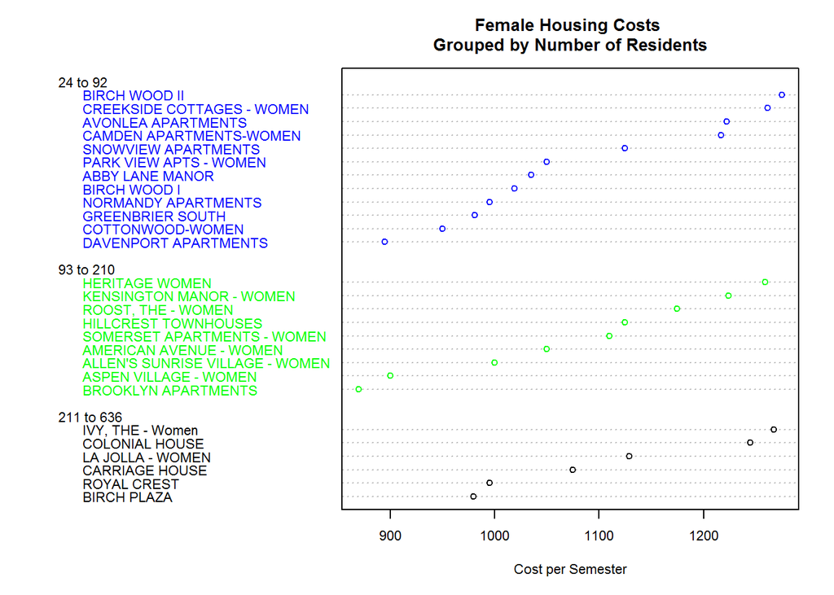

## Interpretation

Stephanie can use this graphic to narrow her search. She says that cost and size of the complex are he criteria; but, she may want research other aspects of these 27 complexes for intangibles not contained in the dataset.

[^1]: Note that Stephanie is a fictional character who is based on real experiences of many faculty and staff here at BYU-Idaho.